# PCA_METEOROLOGÍA

2025-03-26

```r
# Cargar librerías
library(dplyr)
library(FactoMineR)
library(factoextra)
library(lubridate)
```

```r
library(ggplot2)
library(gridExtra)
library(readr)
```

```r
df <- read_csv("meteorología_PCA.csv")
```

En este análisis resolvemos el problema de tratar una variable circular, como el ángulo del viento, utilizando una transformación trigonométrica que la convierte en dos variables cartesianas: wind_x = cos(ángulo) y wind_y = sin(ángulo). Esta transformación es necesaria porque los ángulos en grados no son lineales: por ejemplo, 0° y 360° representan la misma dirección (norte), pero numéricamente están muy alejados. Si se utiliza el ángulo directamente en métodos como PCA o clustering, que se basan en distancias y combinaciones lineales, se distorsiona la verdadera relación entre direcciones. Al proyectar cada ángulo sobre el círculo unitario mediante el coseno y el seno, obtenemos dos variables numéricas que reflejan correctamente la orientación del viento en el espacio. De este modo, el análisis estadístico trata el ángulo del viento de forma coherente, respetando su naturaleza circular y mejorando la calidad e interpretación de los resultados.

```r
# Transformar ángulo del viento a coordenadas cartesianas
df <- df %>%
  mutate(
    wind_x = cos(`Ángulo del viento (°)` * pi / 180),
    wind_y = sin(`Ángulo del viento (°)` * pi / 180)
  )
```

```r
# Preparar base para PCA
df_pca <- df %>%
  select(-c("Tiempo", "Dirección del viento", "fecha", "hora", `Ángulo del viento (°)`)) %>%
  mutate(Tiempo_reducido = factor(Tiempo_reducido))
```

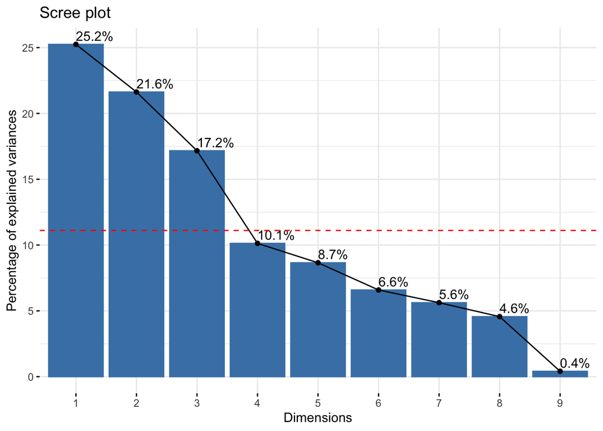

```r
# Posición de variable cualitativa
pos_tiempo <- which(names(df_pca) == "Tiempo_reducido")
# Ejecutar PCA con 10 componentes
res.pca <- PCA(df_pca,
               scale.unit = TRUE,
               ncp = 10,
               graph = FALSE,
               quali.sup = pos_tiempo)

# Visualización de la varianza explicada
fviz_eig(res.pca, addlabels = TRUE) +
  geom_hline(yintercept = 100 / res.pca$call$ncp, linetype = 2, color = "red")
```

```r
# Tabla de varianza explicada
eig.val <- get_eigenvalue(res.pca)
knitr::kable(eig.val[1:8,])
```

|  | eigenvalue | variance.percent | cumulative.variance.percent |
| --- | --- | --- | --- |
| Dim.1 | 2.2721463 | 25.246070 | 25.24607 |
| Dim.2 | 1.9465141 | 21.627934 | 46.87400 |
| Dim.3 | 1.5448251 | 17.164723 | 64.03873 |
| Dim.4 | 0.9114756 | 10.127507 | 74.16623 |
| Dim.5 | 0.7788628 | 8.654031 | 82.82026 |
| Dim.6 | 0.5928374 | 6.587082 | 89.40735 |
| Dim.7 | 0.5059296 | 5.621440 | 95.02879 |
| Dim.8 | 0.4105890 | 4.562100 | 99.59089 |

Tanto el diagrama del codo como la tabla de varianza explicada justifican de forma clara la elección de tres componentes principales para el análisis. En el gráfico, se observa que la “curva del codo” presenta una inflexión notable tras la tercera dimensión: a partir de la cuarta componente, la ganancia en varianza explicada disminuye significativamente. Esto sugiere que añadir más componentes aporta poca información adicional relevante. La tabla refuerza esta conclusión: las tres primeras dimensiones explican juntas aproximadamente el 64.0% de la varianza total del conjunto de datos (25.2% + 21.6% + 17.2%). Este valor es suficientemente alto para captar la estructura esencial de los datos sin necesidad de incorporar dimensiones adicionales que solo añadirían complejidad. Por ello, se considera adecuado continuar el análisis con solo tres componentes, ya que representan un equilibrio entre simplificación y capacidad explicativa.£

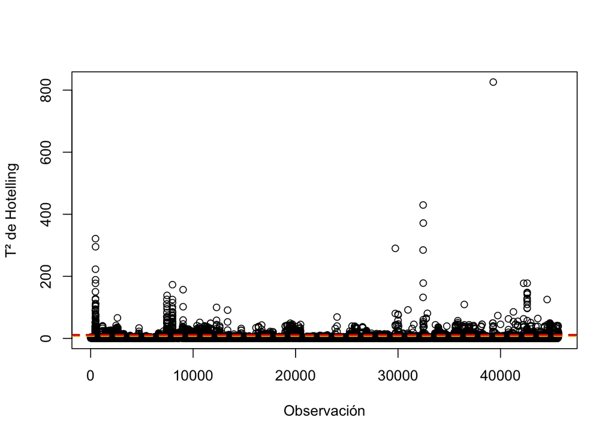

```r
# Definir K (número de componentes a conservar)
K <- 3
# Repetir PCA con K componentes
res.pca <- PCA(df_pca,
               scale.unit = TRUE,
               graph = FALSE,
               ncp = K,
               quali.sup = pos_tiempo)


# Gráfico T² de Hotelling
misScores <- res.pca$ind$coord[, 1:K]
miT2 <- colSums(t(misScores^2) / eig.val[1:K, 1])
I <- nrow(df_pca)
F95 <- K * (I^2 - 1) / (I * (I - K)) * qf(0.95, K, I - K)
F99 <- K * (I^2 - 1) / (I * (I - K)) * qf(0.99, K, I - K)

plot(1:length(miT2), miT2, type = "p", xlab = "Observación", ylab = "T² de Hotelling")
abline(h = F95, col = "orange", lty = 2, lwd = 2)
abline(h = F99, col = "red3", lty = 2, lwd = 2)
```